# T.S Final Project

## 3.5 N225

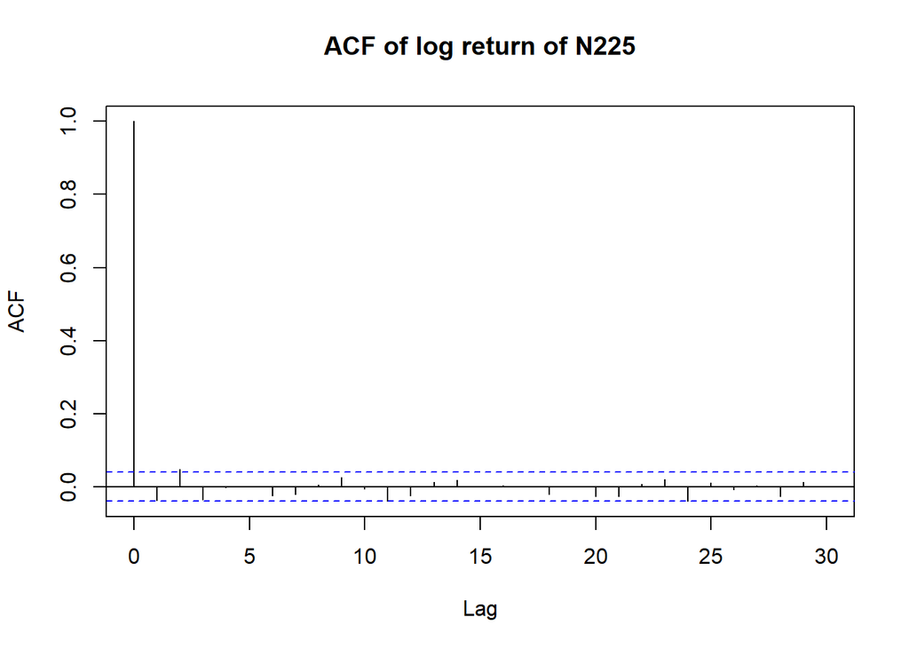

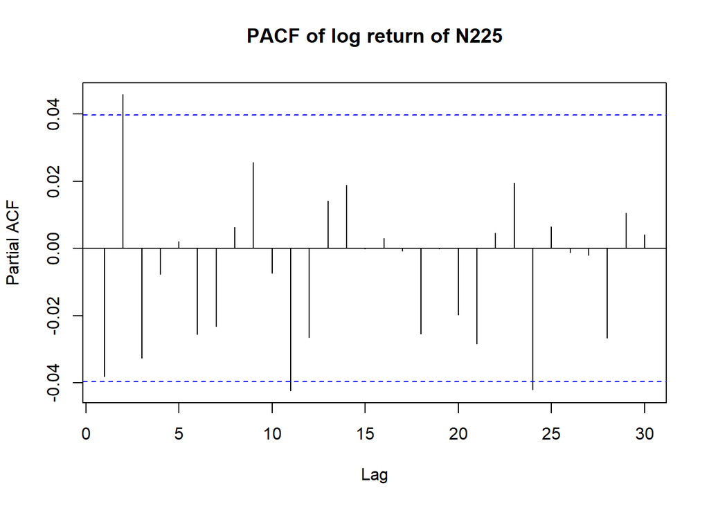

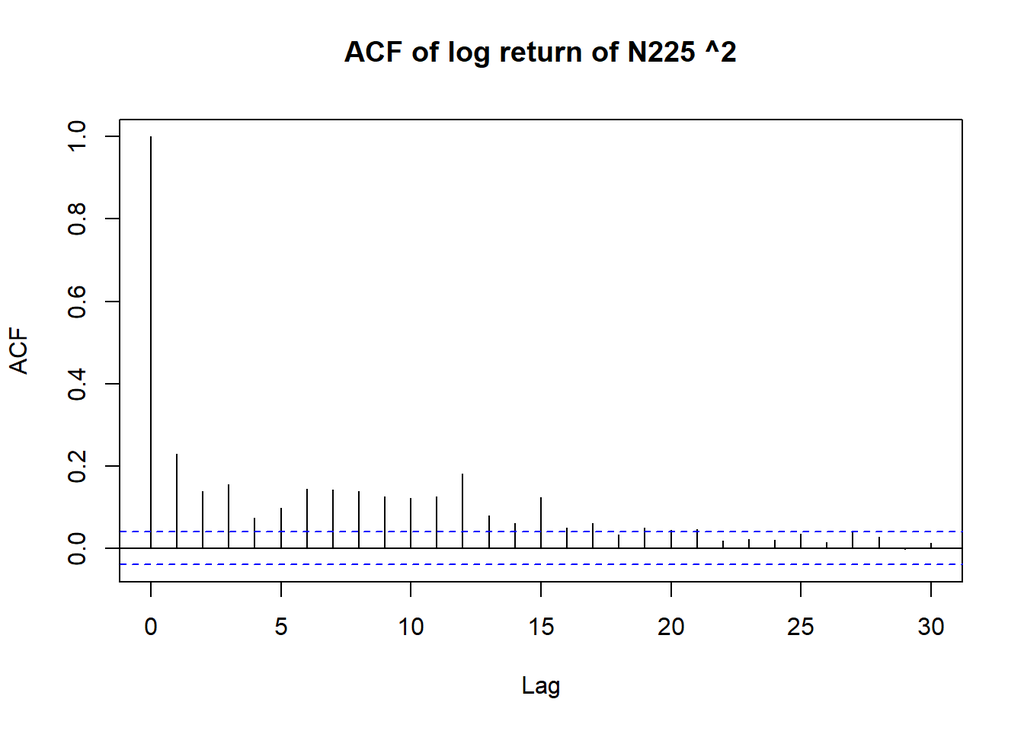

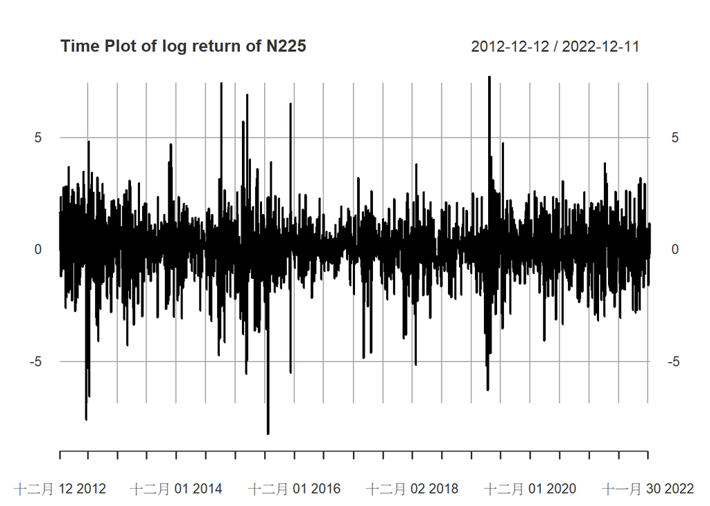

```
##
## Title:
##  Augmented Dickey-Fuller Test
##
## Test Results:
##   PARAMETER:
##     Lag Order: 1
##   STATISTIC:
##     Dickey-Fuller: -33.9814
##   P VALUE:
##     0.01
##
## Description:
##  Mon Jan  2 16:31:52 2023 by user: User
```

```
##
##  Box-Ljung test
##
## data:  logrt.N225
## X-squared = 16.4, df = 10, p-value = 0.08873
```

```
##
##  Box-Ljung test
##
## data:  logrt.N225^2
## X-squared = 491.24, df = 10, p-value < 2.2e-16
```

### 3.5.1 Model Garch(1,1) and residual diagnostic(asuuma residual from skewed standardized T distribution)

```
##
## Title:
##  GARCH Modelling
##
## Call:
##  garchFit(formula = logrt.N225 ~ garch(1, 1), data = logrt.N225,
##     cond.dist = "sstd", trace = FALSE)
##
## Mean and Variance Equation:
##  data ~ garch(1, 1)
## <environment: 0x000001adfc9e3688>
##  [data = logrt.N225]
##
## Conditional Distribution:
##  sstd
##
## Coefficient(s):
##       mu     omega    alpha1     beta1      skew     shape
## 0.063087  0.051110  0.119054  0.858753  0.921316  5.458823
##
## Std. Errors:
##  based on Hessian
##
## Error Analysis:
##         Estimate  Std. Error  t value Pr(>|t|)
## mu       0.06309     0.02188    2.883  0.00393 **
## omega    0.05111     0.01613    3.169  0.00153 **
## alpha1   0.11905     0.02119    5.619 1.92e-08 ***
## beta1    0.85875     0.02440   35.189  < 2e-16 ***
## skew     0.92132     0.02493   36.959  < 2e-16 ***
## shape    5.45882     0.64267    8.494  < 2e-16 ***
## ---
## Signif. codes:  0 '***' 0.001 '**' 0.01 '*' 0.05 '.' 0.1 ' ' 1
##
## Log Likelihood:
##  -3858.936    normalized:  -1.581531
##
## Description:
##  Mon Jan  2 16:31:53 2023 by user: User
##
##
## Standardised Residuals Tests:
##                                 Statistic p-Value
##  Jarque-Bera Test   R    Chi^2  455.3908  0
##  Shapiro-Wilk Test  R    W      0.9781207 0
##  Ljung-Box Test     R    Q(10)  6.443196  0.7767558
##  Ljung-Box Test     R    Q(15)  11.22266  0.7366563
##  Ljung-Box Test     R    Q(20)  17.35673  0.6297032
##  Ljung-Box Test     R^2  Q(10)  7.940613  0.6346379
##  Ljung-Box Test     R^2  Q(15)  14.44928  0.4917633
##  Ljung-Box Test     R^2  Q(20)  17.80868  0.60001
##  LM Arch Test       R    TR^2   13.06035  0.3646696
##
## Information Criterion Statistics:
##      AIC      BIC      SIC     HQIC
## 3.167980 3.182242 3.167968 3.173164
```

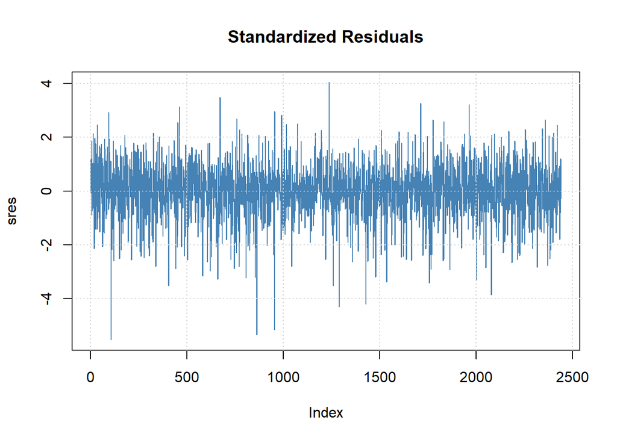

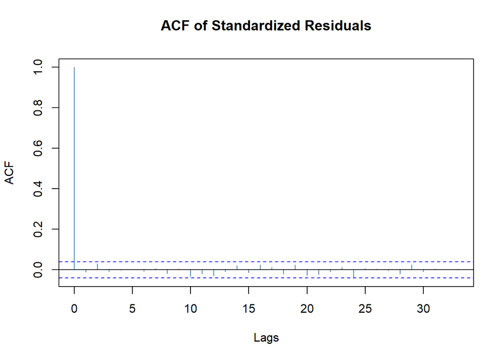

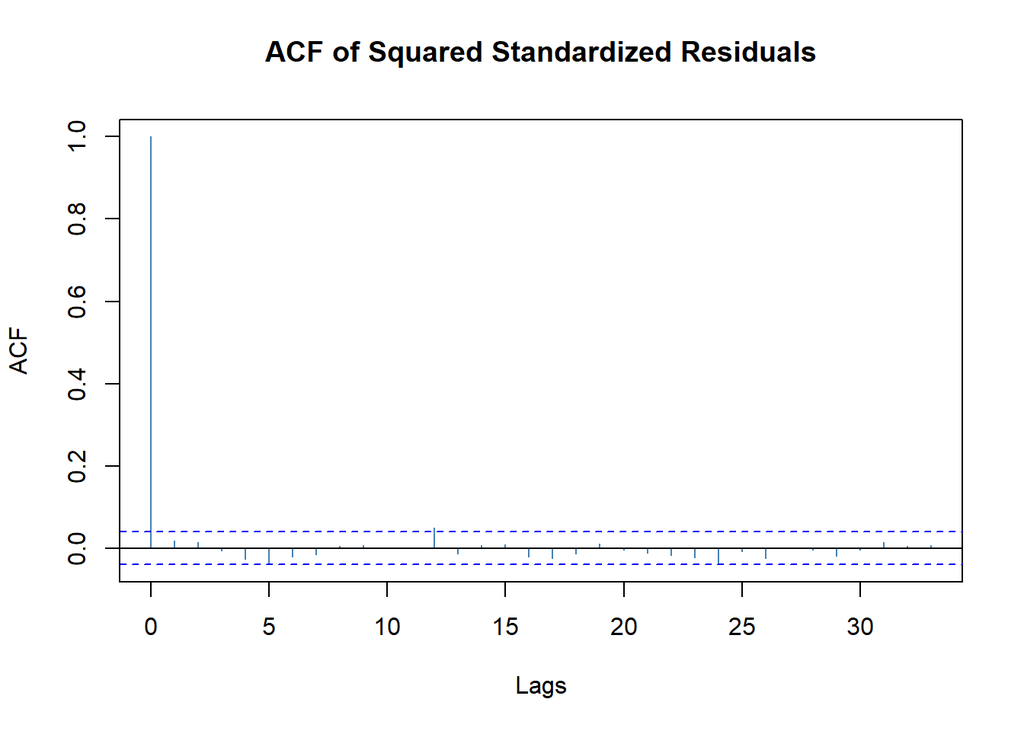

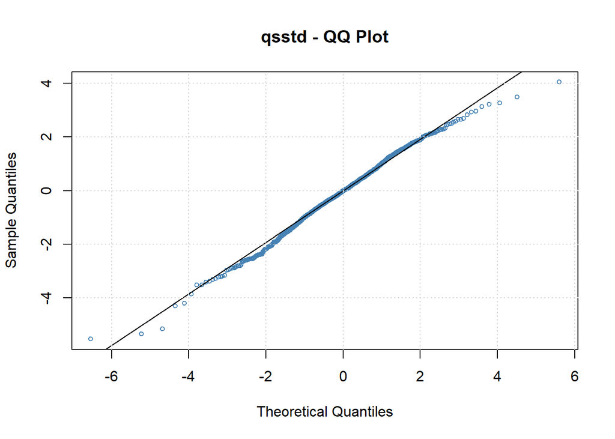

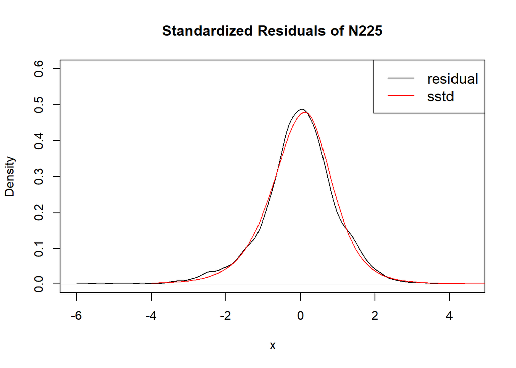

```
##
##  Asymptotic two-sample Kolmogorov-Smirnov test
##
## data:  res.N225 and sstd
## D = 0.034131, p-value = 0.3804
## alternative hypothesis: two-sided
```

## 3.6 NZDJPY

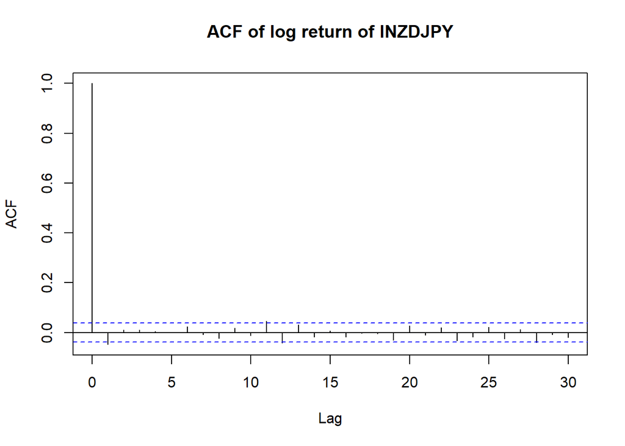

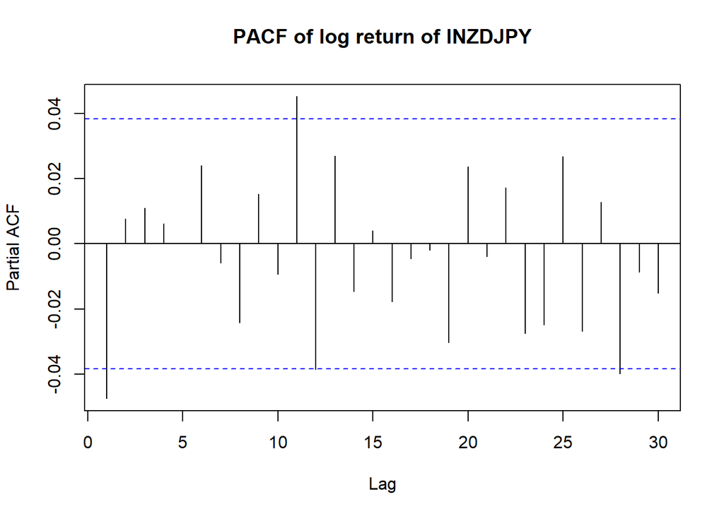

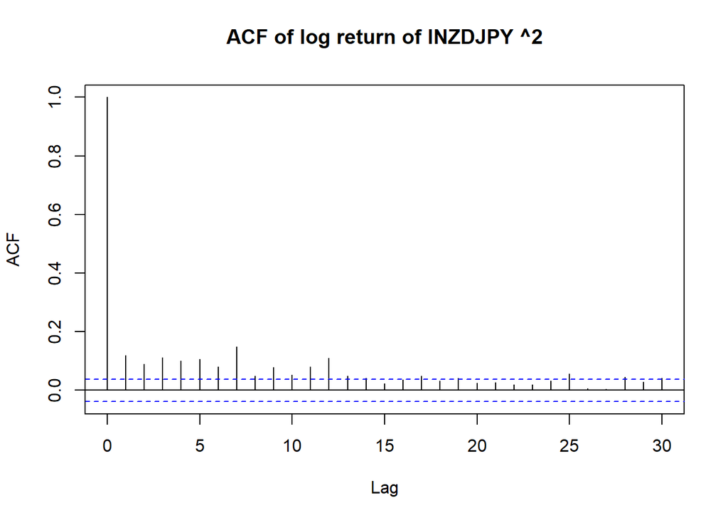

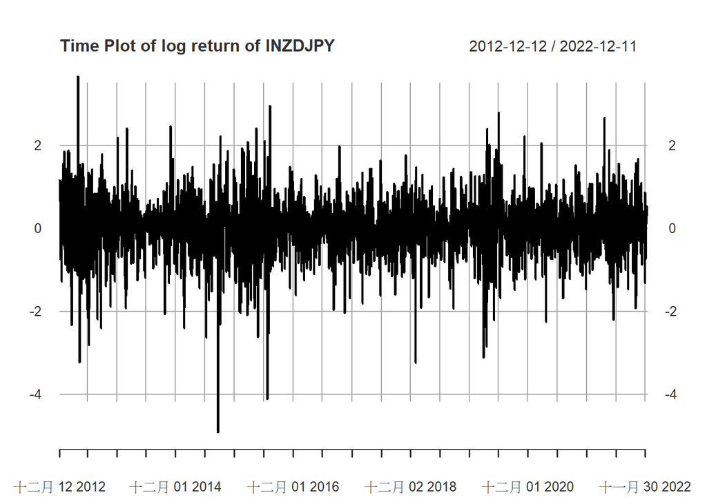

```
##
## Title:
##  Augmented Dickey-Fuller Test
##
## Test Results:
##   PARAMETER:
##     Lag Order: 1
##   STATISTIC:
##     Dickey-Fuller: -36.6429
##   P VALUE:
##     0.01
##
## Description:
##  Mon Jan  2 16:31:54 2023 by user: User
```

```
##
##  Box-Ljung test
##
## data:  logrt.NZDJPY
## X-squared = 10.727, df = 10, p-value = 0.3792
```

```
##
##  Box-Ljung test
##
## data:  logrt.NZDJPY^2
## X-squared = 250.19, df = 10, p-value < 2.2e-16
```

資料經過對數轉換與差分過後皆通過ADF Test，資料的一階動差也沒有序列相關，但二階動差有序列相關性故我們選擇從Garch(1,0)配適模型

```
##
## Title:
##  GARCH Modelling
##
## Call:
##  garchFit(formula = logrt.NZDJPY ~ garch(1, 0), data = logrt.NZDJPY,
##     trace = FALSE)
##
## Mean and Variance Equation:
##  data ~ garch(1, 0)
## <environment: 0x000001adfcd019a0>
##  [data = logrt.NZDJPY]
##
## Conditional Distribution:
##  norm
##
## Coefficient(s):
##       mu     omega    alpha1
## 0.010066  0.442965  0.173616
##
## Std. Errors:
##  based on Hessian
##
## Error Analysis:
##         Estimate  Std. Error  t value Pr(>|t|)
## mu       0.01007     0.01361    0.740    0.459
## omega    0.44297     0.01616   27.409  < 2e-16 ***
## alpha1   0.17362     0.02926    5.934 2.95e-09 ***
## ---
## Signif. codes:  0 '***' 0.001 '**' 0.01 '*' 0.05 '.' 0.1 ' ' 1
##
## Log Likelihood:
##  -2837.763    normalized:  -1.089352
##
## Description:
##  Mon Jan  2 16:31:55 2023 by user: User
##
##
## Standardised Residuals Tests:
##                                 Statistic p-Value
##  Jarque-Bera Test   R    Chi^2  583.4807  0
##  Shapiro-Wilk Test  R    W      0.9793426 0
##  Ljung-Box Test     R    Q(10)  8.151431  0.6140481
##  Ljung-Box Test     R    Q(15)  23.53262  0.07346755
##  Ljung-Box Test     R    Q(20)  31.00304  0.05515038
##  Ljung-Box Test     R^2  Q(10)  125.4411  0
##  Ljung-Box Test     R^2  Q(15)  163.8103  0
##  Ljung-Box Test     R^2  Q(20)  179.001   0
##  LM Arch Test       R    TR^2   109.2539  0
##
## Information Criterion Statistics:
##      AIC      BIC      SIC     HQIC
## 2.181008 2.187762 2.181005 2.183455
```

```
##
## Title:
##  GARCH Modelling
##
## Call:
##  garchFit(formula = logrt.NZDJPY ~ garch(1, 1), data = logrt.NZDJPY,
##     trace = FALSE)
##
## Mean and Variance Equation:
##  data ~ garch(1, 1)
## <environment: 0x000001ad806dcef8>
##  [data = logrt.NZDJPY]
##
## Conditional Distribution:
##  norm
##
## Coefficient(s):
##        mu      omega     alpha1      beta1
## 0.0093497  0.0205439  0.0766726  0.8853717
##
## Std. Errors:
##  based on Hessian
##
## Error Analysis:
##         Estimate  Std. Error  t value Pr(>|t|)
## mu      0.009350    0.012903    0.725  0.46870
## omega   0.020544    0.006933    2.963  0.00304 **
## alpha1  0.076673    0.015704    4.882 1.05e-06 ***
## beta1   0.885372    0.026122   33.894  < 2e-16 ***
## ---
## Signif. codes:  0 '***' 0.001 '**' 0.01 '*' 0.05 '.' 0.1 ' ' 1
##
## Log Likelihood:
##  -2752.264    normalized:  -1.056531
##
## Description:
##  Mon Jan  2 16:31:55 2023 by user: User
##
##
## Standardised Residuals Tests:
##                                 Statistic p-Value
##  Jarque-Bera Test   R    Chi^2  779.0751  0
##  Shapiro-Wilk Test  R    W      0.9805303 0
##  Ljung-Box Test     R    Q(10)  7.36089   0.6909917
##  Ljung-Box Test     R    Q(15)  24.27607  0.06055124
##  Ljung-Box Test     R    Q(20)  28.85664  0.09062078
##  Ljung-Box Test     R^2  Q(10)  6.054447  0.8106682
##  Ljung-Box Test     R^2  Q(15)  11.4923   0.7169801
##  Ljung-Box Test     R^2  Q(20)  12.29557  0.9055272
##  LM Arch Test       R    TR^2   8.781118  0.7215035
##
## Information Criterion Statistics:
##      AIC      BIC      SIC     HQIC
## 2.116134 2.125140 2.116129 2.119396
```

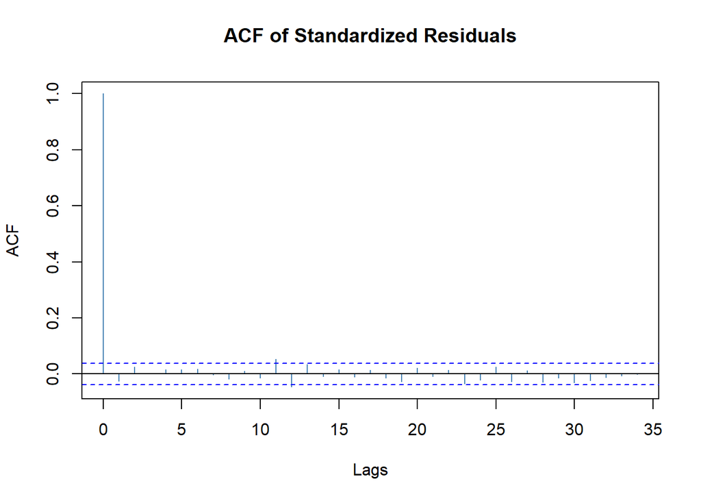

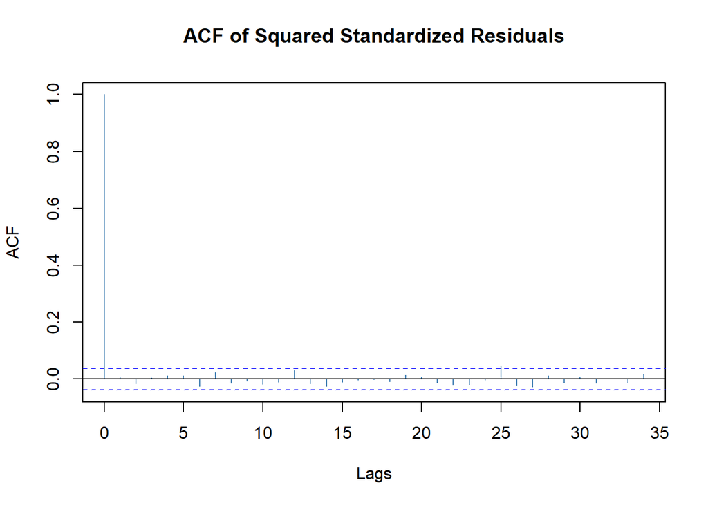

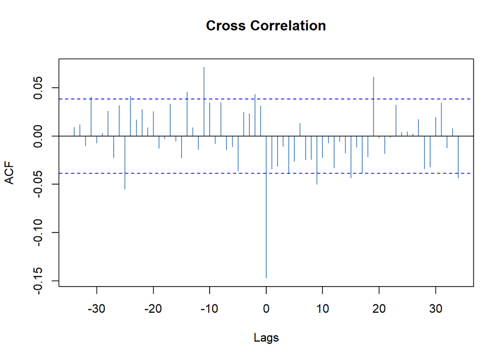

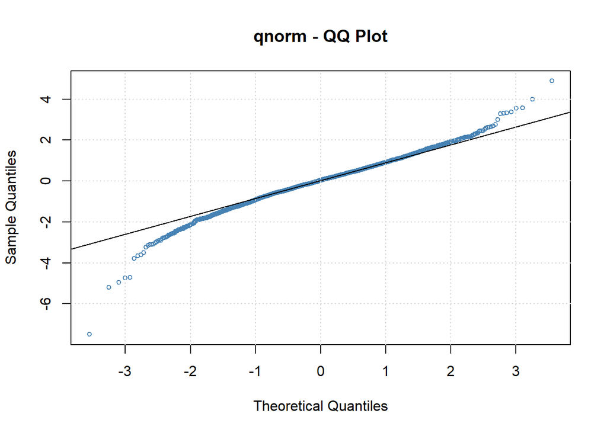

```
##
## Title:
##  GARCH Modelling
##
## Call:
##  garchFit(formula = logrt.NZDJPY ~ garch(1, 1), data = logrt.NZDJPY,
##     cond.dist = "std", trace = FALSE)
##
## Mean and Variance Equation:
##  data ~ garch(1, 1)
## <environment: 0x000001adfed037b0>
##  [data = logrt.NZDJPY]
##
## Conditional Distribution:
##  std
##
## Coefficient(s):
##       mu     omega    alpha1     beta1     shape
## 0.019073  0.019458  0.086314  0.878615  6.938045
##
## Std. Errors:
##  based on Hessian
##
## Error Analysis:
##         Estimate  Std. Error  t value Pr(>|t|)
## mu      0.019073    0.012082    1.579  0.11443
## omega   0.019458    0.007076    2.750  0.00596 **
## alpha1  0.086314    0.017915    4.818 1.45e-06 ***
## beta1   0.878615    0.027428   32.034  < 2e-16 ***
## shape   6.938045    0.870836    7.967 1.55e-15 ***
## ---
## Signif. codes:  0 '***' 0.001 '**' 0.01 '*' 0.05 '.' 0.1 ' ' 1
##
## Log Likelihood:
##  -2687.968    normalized:  -1.031849
##
## Description:
##  Mon Jan  2 16:31:55 2023 by user: User
##
##
## Standardised Residuals Tests:
##                                 Statistic p-Value
##  Jarque-Bera Test   R    Chi^2  777.5004  0
##  Shapiro-Wilk Test  R    W      0.9803603 0
##  Ljung-Box Test     R    Q(10)  7.000934  0.7253568
##  Ljung-Box Test     R    Q(15)  24.11641  0.06314286
##  Ljung-Box Test     R    Q(20)  28.71692  0.09348467
##  Ljung-Box Test     R^2  Q(10)  6.334438  0.7864263
##  Ljung-Box Test     R^2  Q(15)  12.13702  0.6686295
##  Ljung-Box Test     R^2  Q(20)  12.99709  0.8775088
##  LM Arch Test       R    TR^2   8.999001  0.7030157
##
## Information Criterion Statistics:
##      AIC      BIC      SIC     HQIC
## 2.067538 2.078795 2.067530 2.071616
```

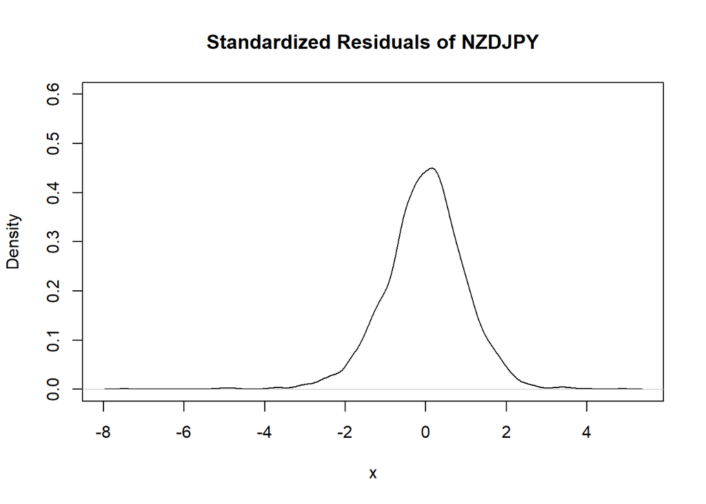

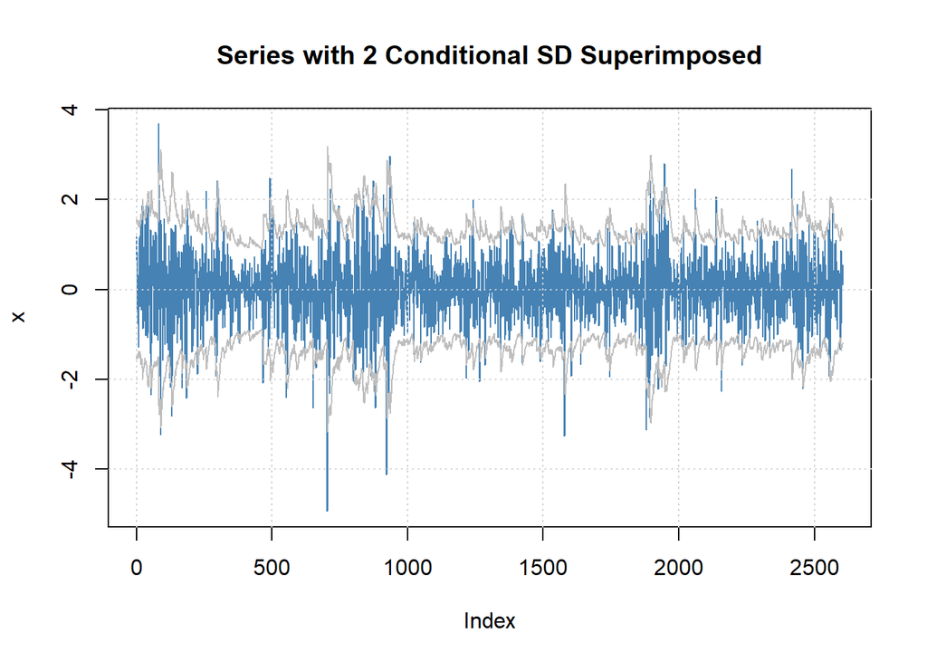

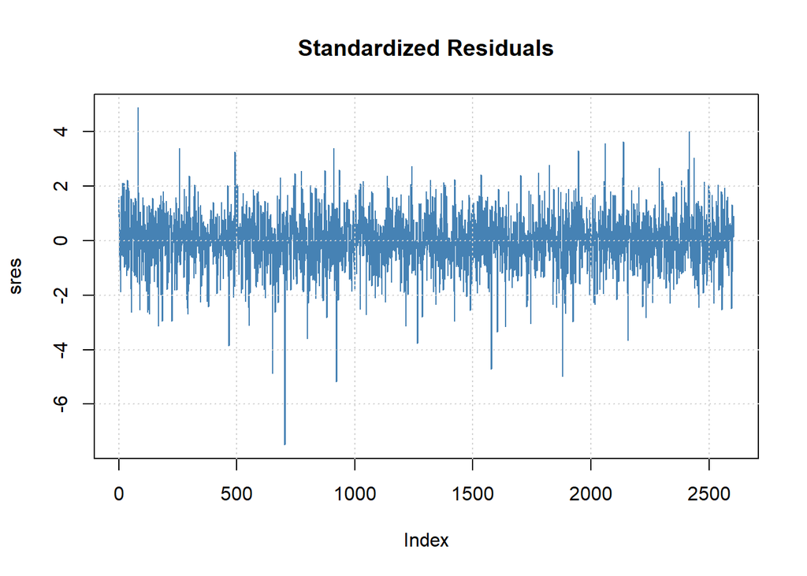

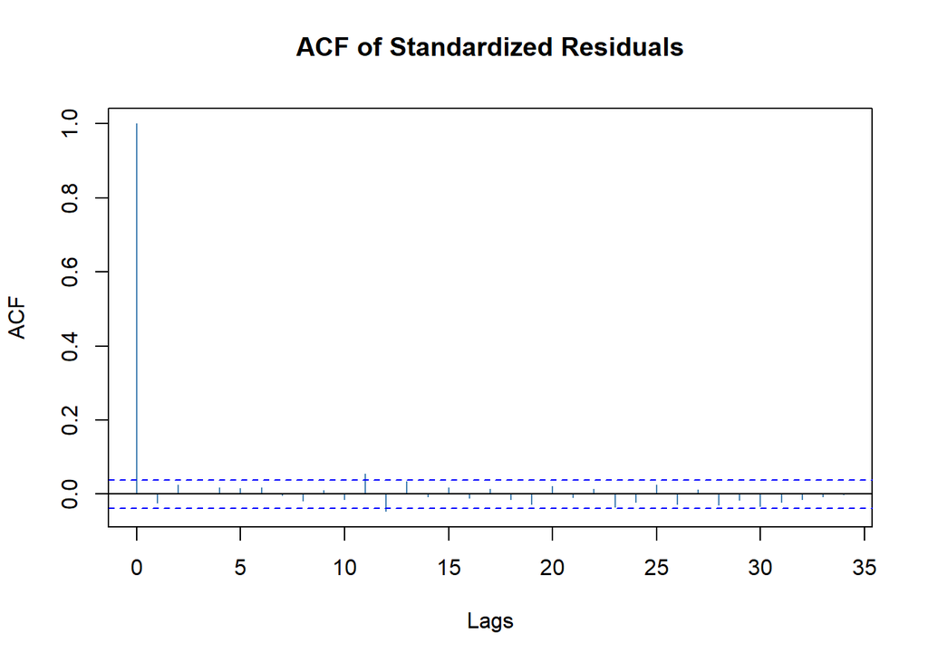

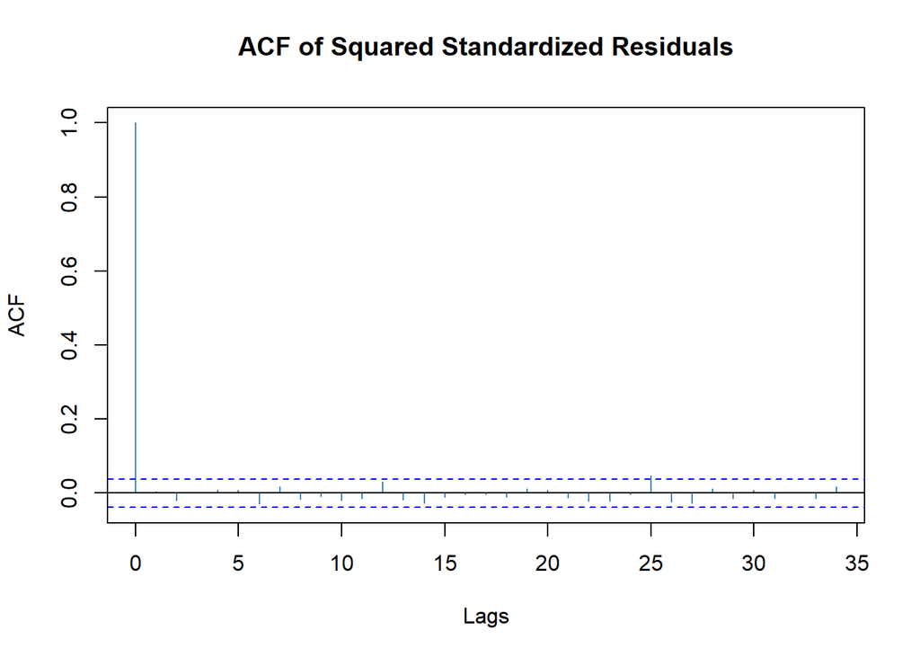

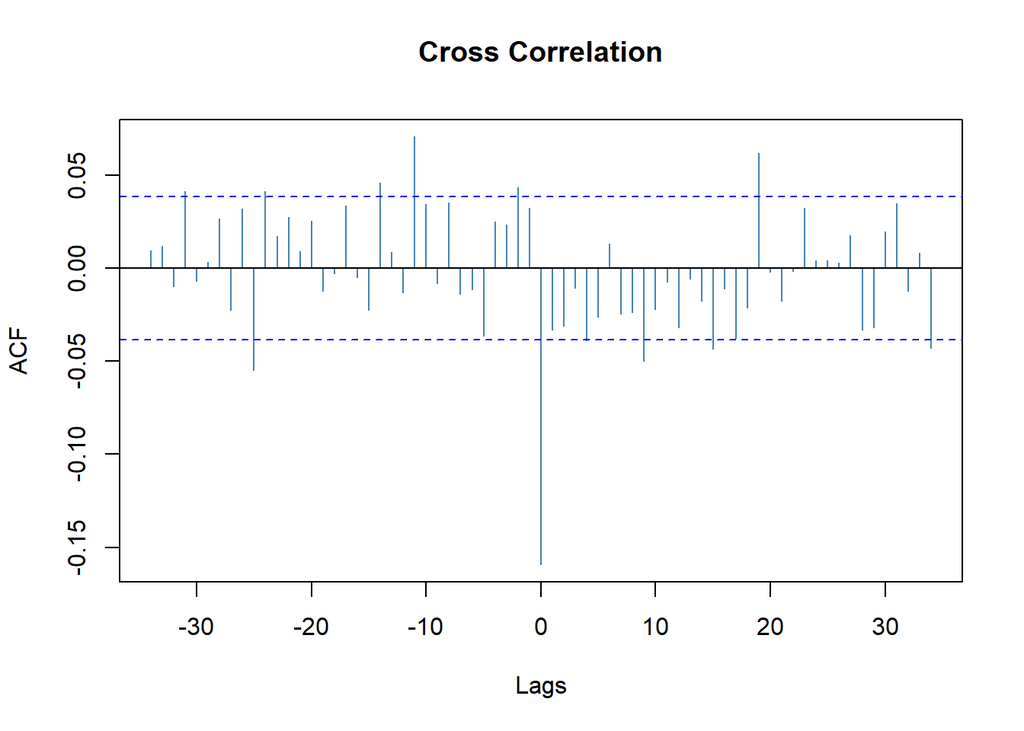

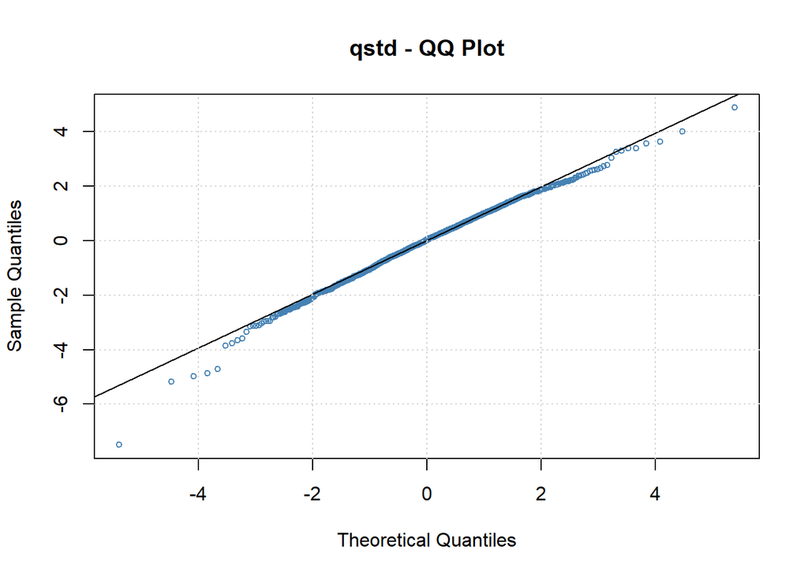

```
##
##  Asymptotic two-sample Kolmogorov-Smirnov test
##
## data:  residuals(g.NZDJPY, standardize = T) and rstd(250, nu = 6.938045)
## D = 0.06271, p-value = 0.331
## alternative hypothesis: two-sided
```

```
##
## Title:
##  GARCH Modelling
##
## Call:
##  garchFit(formula = logrt.NZDJPY ~ garch(1, 1), data = logrt.NZDJPY,
##     cond.dist = "sstd", trace = FALSE)
##
## Mean and Variance Equation:
##  data ~ garch(1, 1)
## <environment: 0x000001adfe01a5c8>
##  [data = logrt.NZDJPY]
##
## Conditional Distribution:
##  sstd
##
## Coefficient(s):
##        mu      omega     alpha1      beta1       skew      shape
## 0.0066661  0.0187420  0.0861845  0.8801195  0.9169843  7.0941366
##
## Std. Errors:
##  based on Hessian
##
## Error Analysis:
##         Estimate  Std. Error  t value Pr(>|t|)
## mu      0.006666    0.012670    0.526  0.59881
## omega   0.018742    0.006717    2.790  0.00527 **
## alpha1  0.086184    0.017400    4.953 7.30e-07 ***
## beta1   0.880120    0.026269   33.504  < 2e-16 ***
## skew    0.916984    0.025240   36.330  < 2e-16 ***
## shape   7.094137    0.911456    7.783 7.11e-15 ***
## ---
## Signif. codes:  0 '***' 0.001 '**' 0.01 '*' 0.05 '.' 0.1 ' ' 1
##
## Log Likelihood:
##  -2683.032    normalized:  -1.029955
##
## Description:
##  Mon Jan  2 16:31:57 2023 by user: User
##
##
## Standardised Residuals Tests:
##                                 Statistic p-Value
##  Jarque-Bera Test   R    Chi^2  791.568   0
##  Shapiro-Wilk Test  R    W      0.9802028 0
##  Ljung-Box Test     R    Q(10)  7.067078  0.7190976
##  Ljung-Box Test     R    Q(15)  24.16892  0.06227991
##  Ljung-Box Test     R    Q(20)  28.76609  0.09246823
##  Ljung-Box Test     R^2  Q(10)  6.355716  0.7845449
##  Ljung-Box Test     R^2  Q(15)  12.0906   0.6721589
##  Ljung-Box Test     R^2  Q(20)  13.0054   0.8771522
##  LM Arch Test       R    TR^2   8.842799  0.7162956
##
## Information Criterion Statistics:
##      AIC      BIC      SIC     HQIC
## 2.064516 2.078025 2.064506 2.069410
```

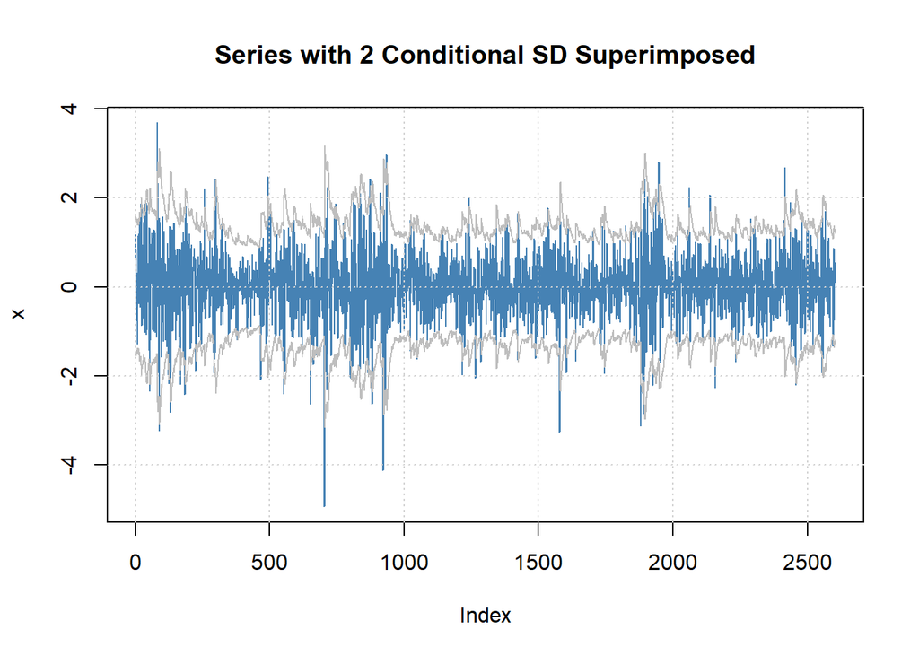

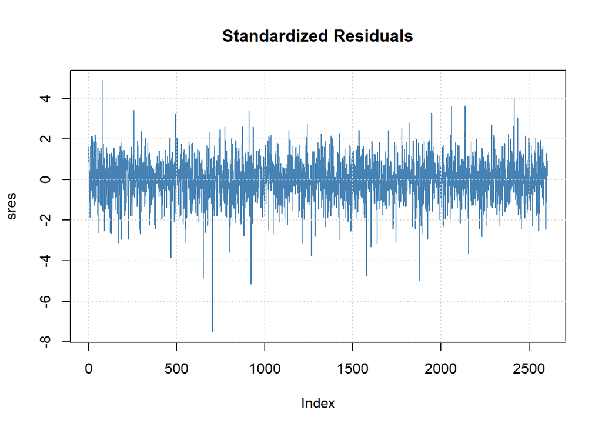

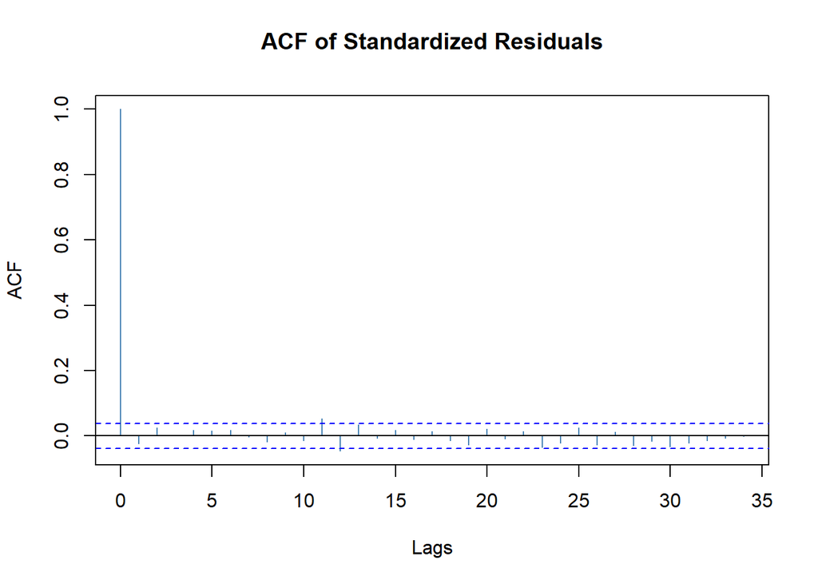

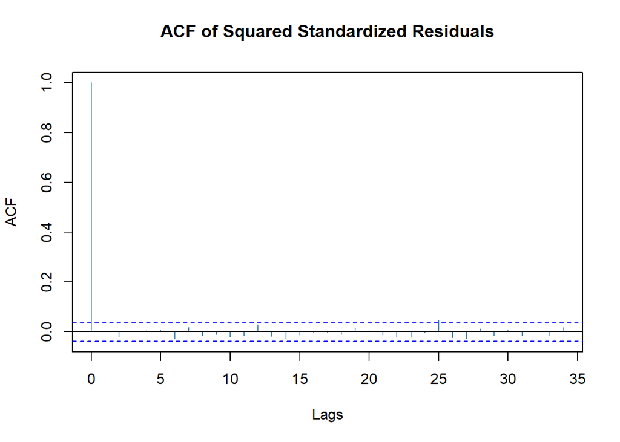

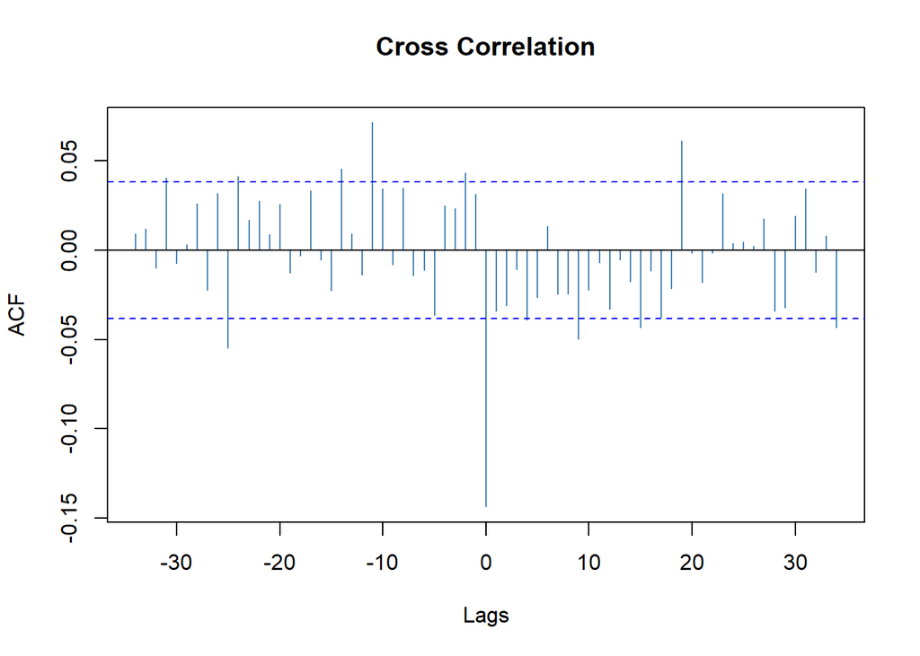

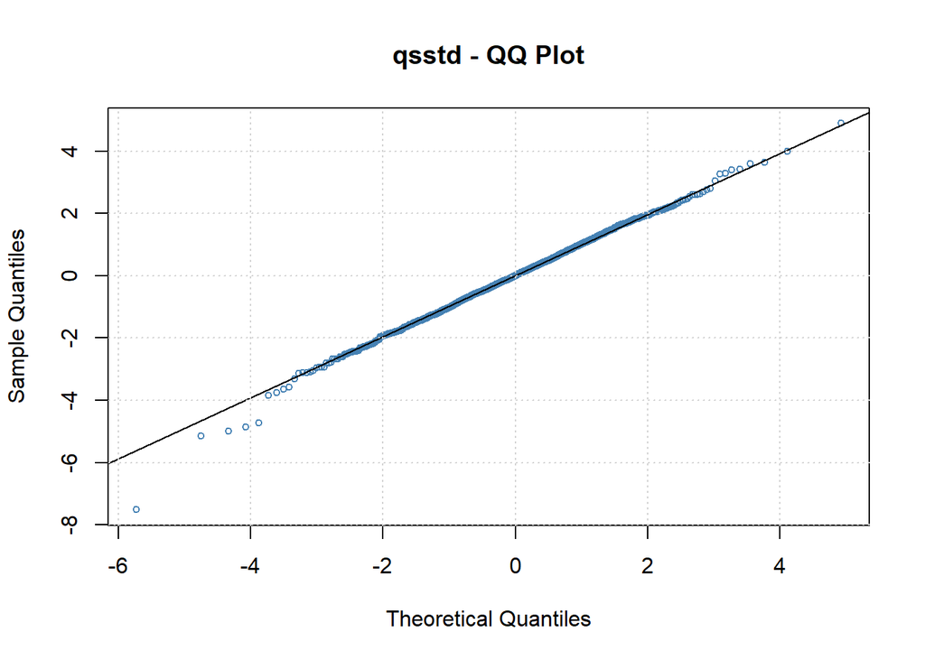

```
##
##  Asymptotic two-sample Kolmogorov-Smirnov test
##
## data:  residuals(g.NZDJPY, standardize = T) and rsstd(250, nu = 7.094137, xi = 0.916984)
## D = 0.06575, p-value = 0.2776
## alternative hypothesis: two-sided
```

我們從aic、bic來判斷兩模型，殘差來自偏斜標準T分配的Garch(1,1)比殘差來自標準T分配的Garch(1,1)較好。